# Machine Prediction of Exercise Results

John W. Hoggard

7/4/2017

## Problem

We have data regarding a variety of measures taken from sensors on a person’s body while they performed an exercise, and a classification of whether the activity was performed correctly or featuring one of four common errors. The data was analyzed in a 2013 paper[^1] and is available at http://groupware.les.inf.puc-rio.br/har. The data includes a variable `classe` which contains a classification code (`A` through `E`) for how the exercise was performed. Our task is to predict `classe` based off of the other available data.

## Importing and Cleaning Data

Data for training was provided in a file `pml-training.csv`. To begin the analysis, we import the data:

```r
train.data <- read.table("pml-training.csv", header=TRUE, sep=",", stringsAsFactors=FALSE)
```

We note that a large number of columns here are mostly blank or mostly filled with NAs. Blank columns have imported as character type, so we eliminate these, and the columns that are mostly NA, but keep character values which we might use. We also convert the variable `classe` (which contains the classification of how the exercise was completed) to a factor variable:

```r
keep <- !(sapply(train.data, class)=="character")
keep[c("user_name", "cvtd_timestamp", "new_window", "classe")]<- TRUE
train.data <- train.data[, keep]
train.data <- train.data[,(sapply(train.data, function(x) {sum(is.na(x))}) < 19000)]
train.data$classe<-as.factor(train.data$classe)
```

For cross-validation, we will select a subset of this data for training, and retain the remainder for testing at the end:

```r
library(caret)
inTrain<-createDataPartition(train.data$classe, p=.7, list=FALSE)
trTrain <- train.data[inTrain,]
trTest <- train.data[-inTrain,]
```

## Discriminant Analysis

```r
modQDAS <- train(classe ~., method="qda", data=trTrain[,-c(1:7)])
confusionMatrix(predict(modQDAS, trTest), trTest$classe)$overall[1]
```

```
##  Accuracy
## 0.8973662
```

(Here we exclude the first seven variables from consideration, as these include details such as the test case and the name of the subject which should not be used.) This is fairly good, despite the fact that examination of some of the variables suggests that the data is probably not normally distributed.

## Tree Models

Given the potentially non-linear nature of the prediction required, we consider a classification tree, and use `rpart` to create one:

```r
modTreeFit <- train(classe ~ ., method="rpart", data=trTrain[,-c(1:7)])
confusionMatrix(predict(modTreeFit, trTrain), trTrain$classe)$overall[1]
```

```
##  Accuracy
## 0.5046226
```

Here, in-sample accuracty is only about 50%, so we choose to expand the tree model to a random forest. We move to bootstrapping via random forests to improve the predictive power of the model.

```r
modRFs <- train(classe~., method="rf", data=trTrain[,-c(1:7)])
predRFs <- predict(modRFs, trTrain)
confusionMatrix(predRFs, trTrain$classe)$accuracy[1]
```

[output not shown]

The model defaults to using 500 trees. However, checking the error rates versus number of trees, it appears we achieve most of the accuracy by the time we reach 50 trees:

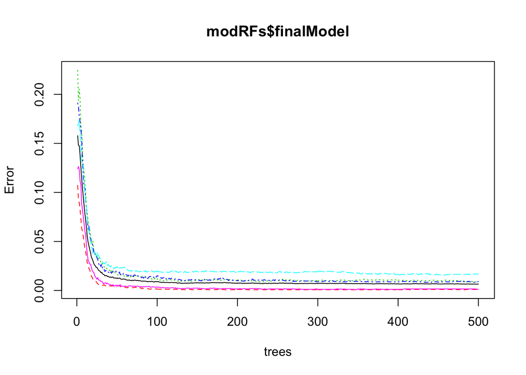

```r
plot(modRFs$finalModel)
```

```r
control <- trainControl(method="repeatedcv", number=10, repeats=3)
mod50TreeRFs <- train(as.factor(classe)~., method="rf", data=trTrain[,-c(1:7)],
                      ntree=50, metric="Accuracy", trControl=control)
mod50TreeRFs$finalModel
```

```
##
## Call:
##  randomForest(x = x, y = y, ntree = 50, mtry = param$mtry)
##                Type of random forest: classification
##                      Number of trees: 50
## No. of variables tried at each split: 27
##
##         OOB estimate of  error rate: 1%
## Confusion matrix:
##      A    B    C    D    E class.error
## A 3895    9    1    0    1 0.002816180
## B   30 2611   12    5    0 0.017682468
## C    0   13 2370   13    0 0.010851419
## D    2    2   26 2220    2 0.014209591
## E    1    3    7   11 2503 0.008712871
```

```r
confusionMatrix(predict(mod50TreeRFs, trTest), trTest$classe)$overall[1]
```

[output not shown]

## Conclusion and Accuracy

We finally check the out-of-sample error rate for our random forest model developed above using the test data we set aside at the start of the analysis:

```r
confusionMatrix(predict(mod50TreeRFs, trTest), trTest$classe)
```

```
## Confusion Matrix and Statistics
##
##           Reference
## Prediction    A    B    C    D    E
##          A 1672    7    0    0    0
##          B    2 1128    4    0    0
##          C    0    3 1017   15    1
##          D    0    1    5  947    2
##          E    0    0    0    2 1079
##
## Overall Statistics
##
##                Accuracy : 0.9929
##                  95% CI : (0.9904, 0.9949)
##     No Information Rate : 0.2845
##     P-Value [Acc > NIR] : < 2.2e-16
##
##                   Kappa : 0.991
##  Mcnemar's Test P-Value : NA
##
## Statistics by Class:
##
##                      Class: A Class: B Class: C Class: D Class: E
## Sensitivity            0.9988   0.9903   0.9912   0.9824   0.9972
## Specificity            0.9983   0.9987   0.9961   0.9984   0.9996
## Pos Pred Value         0.9958   0.9947   0.9817   0.9916   0.9981
## Neg Pred Value         0.9995   0.9977   0.9981   0.9966   0.9994
## Prevalence             0.2845   0.1935   0.1743   0.1638   0.1839
## Detection Rate         0.2841   0.1917   0.1728   0.1609   0.1833
## Detection Prevalence   0.2853   0.1927   0.1760   0.1623   0.1837
## Balanced Accuracy      0.9986   0.9945   0.9937   0.9904   0.9984
```

Indeed, the out-of-sample error rate seems to be very small, with about 99% accuracy of the random forest model on the test data, giving an error rate of 1% or less. This seems to have been a good choice for the model.

## Quiz Prediction

For the quiz, we also import the needed test data, and process (converting answers from numeric to letters A-E for convenience.) Output supressed here.

```r
test.data <- read.table("pml-testing.csv", header=TRUE, sep=",", stringsAsFactors = FALSE)
data.frame(ANS = c("A", "B", "C", "D", "E")[predict(mod50TreeRFs, test.data)])
```

The model correctly predicted all answers.

[^1]: Velloso, E.; Bulling, A.; Gellersen, H.; Ugulino, W.; Fuks, H. Qualitative Activity Recognition of Weight Lifting Exercises. **Proceedings of 4th International Conference in Cooperation with SIGCHI** (Augmented Human ’13) . Stuttgart, Germany: ACM SIGCHI, 2013.